# assignment

Jesslyn Jesslyn

2025-03-23

```r
suppressPackageStartupMessages({
  library(rtracklayer)
  library(epiwraps)
})
```

## Using peaks from ENCODE, identify bivalent domains (H3K27me3 + H3K4me3) from (mouse or human) embryonic stem cells (ESC)

Using mouse ESC:

```r
download.file("https://www.encodeproject.org/files/ENCFF008XKX/@@download/ENCFF008XKX.bed.gz", "h3k27me3_esc.bed.gz")
h3k27me3_esc <- rtracklayer::import("h3k27me3_esc.bed.gz", format="narrowPeak")

download.file("https://www.encodeproject.org/files/ENCFF974BMC/@@download/ENCFF974BMC.bed.gz", "h3k4me3_esc.bed.gz")
h3k4me3_esc <- rtracklayer::import("h3k4me3_esc.bed.gz", format="narrowPeak")
```

```r
## find bivalent domains
esc_overlap <- findOverlapPairs(h3k27me3_esc, h3k4me3_esc)
head(esc_overlap)
```

```
## Pairs object with 6 pairs and 0 metadata columns:
##                          first                   second
##                      <GRanges>                <GRanges>
##   [1]   chr1:10232706-10232952   chr1:10231731-10233519
##   [2] chr1:104994058-104994548 chr1:104993805-104994492
##   [3] chr1:106713380-106713952 chr1:106713477-106714313
##   [4]   chr1:10993516-10993922   chr1:10993429-10994211
##   [5] chr1:120340545-120342095 chr1:120340495-120341892
##   [6] chr1:120596975-120597821 chr1:120596863-120597110
```

```r
esc_bivalent <- punion(esc_overlap)
head(ranges(esc_bivalent))
```

```
## IRanges object with 6 ranges and 0 metadata columns:
##           start       end     width
##       <integer> <integer> <integer>
##   [1]  10231731  10233519      1789
##   [2] 104993805 104994548       744
##   [3] 106713380 106714313       934
##   [4]  10993429  10994211       783
##   [5] 120340495 120342095      1601
##   [6] 120596863 120597821       959
```

*Question: what happens to those regions upon differentiation?*

- Choose *one* differentiated cell type (e.g. erythroblasts, fibroblast, B cells, etc.)

Myoblast cells: C2C12 cell line

- Download the H3K27me3 and H3K4me3 peaks from this cell type

```r
download.file("https://www.encodeproject.org/files/ENCFF071FEL/@@download/ENCFF071FEL.bed.gz", "h3k27me3_diff.bed.gz")
h3k27me3_diff <- rtracklayer::import("h3k27me3_diff.bed.gz", format="narrowPeak")

download.file("https://www.encodeproject.org/files/ENCFF635VQE/@@download/ENCFF635VQE.bed.gz", "h3k4me3_diff.bed.gz")
h3k4me3_diff <- rtracklayer::import("h3k4me3_diff.bed.gz", format="narrowPeak")
```

- How many of the mESC bivalent domains are, in this differentiated cell type, overlapping either mark or their combination (in this differentiated cell type)?
1. 1972 of the mESC bivalent domains overlap with H3K27me3 peaks of the differentiated cell line.
2. 1133 of the mESC bivalent domains overlap with H3K4me3 peaks of the differentiated cell line.
3. 224 of the mESC bivalent domains overlap with both H3K27me3 and H3K4me3 peaks of the differentiated cell line.

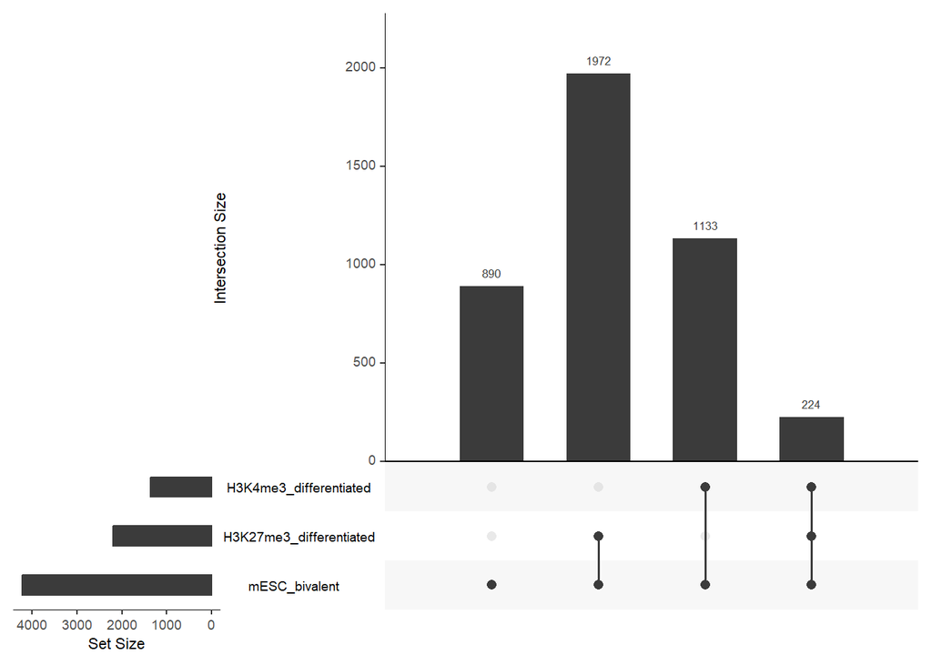

```r
peaks <- list(h3k27me3_diff, h3k4me3_diff, esc_bivalent)
names(peaks) <- c("H3K27me3_differentiated", "H3K4me3_differentiated", "mESC_bivalent")
regionUpset(peaks, reference = peaks$mESC_bivalent, nsets=length(peaks))
```

(You can use either mouse or human data, just make sure you do everything with the same species!)